# 20191111 Data Cleaning

Hanqian Zhang

11/12/2019

## Setup

### Load Packages

```r
library(ggplot2)
library(dplyr)
library(statsr)
library(gmodels)
```

### Load Data

```r
library(haven)
cfps2018person_201909 <- read_dta("D:/CFPS Research-20191101T212903Z-001/CFPS Research/Data/[CFPS+Public+Data]+CFPS+2018+in+STATA+(Chinese)/[CFPS Public Data] CFPS 2018 in STATA (Chinese)/cfps2018person_201909.dta")
library(haven)
cfps2018famecon_201909 <- read_dta("D:/CFPS Research-20191101T212903Z-001/CFPS Research/Data/[CFPS+Public+Data]+CFPS+2018+in+STATA+(Chinese)/[CFPS Public Data] CFPS 2018 in STATA (Chinese)/cfps2018famecon_201909.dta")
```

### 添加新列：劳务派遣

在该步骤后保留的变量如下：

| Num | var | label |
| --- | --- | --- |
| 1 | pid | 个人id |
| 2 | qa001b | 年龄 |
| 3 | gender | 性别 |
| 4 | dispatch | 雇佣方法 |
| 5 | qg12 | 工作总收入 |
| 6 | qg10 | 是否提供公积金 |
| 7 | qg1001 | 月度公积金数额 |
| 8 | qg901 | 个人每月缴纳多少钱的保险 |
| 9 | qg702 | 过去一年的福利金额 |
| 10 | qn4003 | 工会成员 |
| 11 | qg401 | 工作收入满意度 |
| 12 | qg406 | 工作总体满意度 |
| 13 | qg15 | 过去12个月是否升迁 |
| 14 | qn10025 | 对政府官员信任程度 |
| 15 | qn6011 | 认为政府腐败问题有多严重 |
| 16 | qn6014 | 我国就业问题有多严重 |
| 17 | qn6018 | 我国社会保障问题有多严重 |

所有小于0的数值都被调整为NA。

```r
employment2018 <- cfps2018person_201909 %>%
  filter(!(is.na(qg502)), qg5 == 1, qg502 > 0)
```

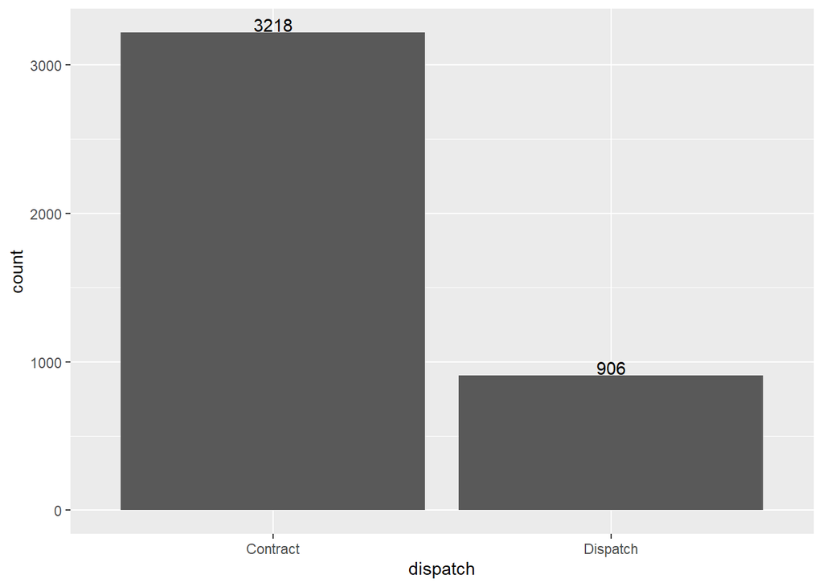

```r
employment2018 <- employment2018 %>%
  mutate(dispatch = ifelse(qg502 == 1, "Dispatch", "Contract"))


ggplot(employment2018, aes(x = dispatch)) +
  geom_histogram(stat="count") +
  geom_text(stat = "count", aes(label=..count..), vjust = -0.1)
```

```r
employment2018 <- employment2018[c("pid", "qa001b", "gender", "dispatch", "qg12", "qg10", "qg1001", "qg901", "qg702", "qn4003", "qg401", "qg406", "qg15", "qn10025", "qn6011", "qn6014", "qn6018")]
```

```r
employment2018[employment2018 < 0] <- NA
```

### 绘制箱图

给以下四个变量绘制箱图

| Num | var | label |
| --- | --- | --- |
| 1 | qg12 | 工作总收入 |
| 2 | qg1001 | 月度公积金数额 |
| 3 | qg901 | 个人每月缴纳多少钱的保险 |
| 4 | qg702 | 过去一年的福利金额 |

#### 工作总收入

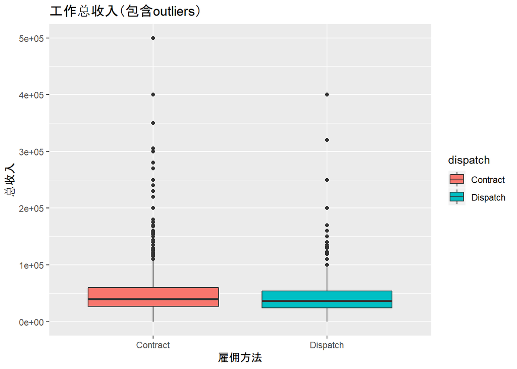

```r
ggplot(data = subset(employment2018, !is.na(qg12)), aes(x = dispatch, y = qg12)) +
  geom_boxplot(aes(fill = dispatch)) +
  labs(x = "雇佣方法", y = "总收入") +
  ggtitle("工作总收入（包含outliers）")
```

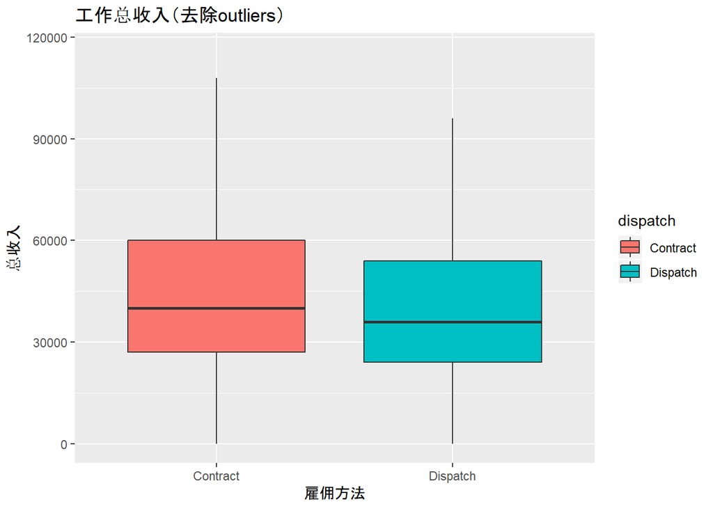

```r
ylim1 = boxplot.stats(employment2018$qg12)$stats[c(1, 5)]

ggplot(data = subset(employment2018, !is.na(qg12)), aes(x = dispatch, y = qg12)) +
  geom_boxplot(aes(fill = dispatch), outlier.shape = NA) +
  labs(x = "雇佣方法", y = "总收入") +
  ggtitle("工作总收入（去除outliers）") +
  coord_cartesian(ylim = ylim1 * 1.05)
```

#### 月度公积金数额

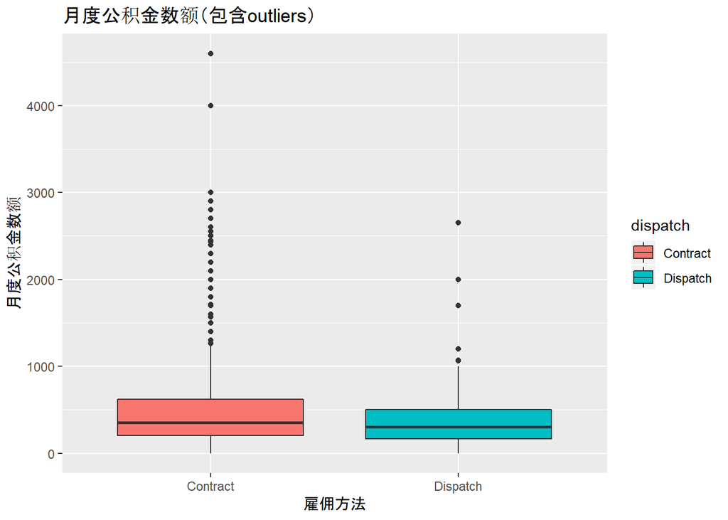

```r
ggplot(data = subset(employment2018, !is.na(qg1001)), aes(x = dispatch, y = qg1001)) +
  geom_boxplot(aes(fill = dispatch)) +
  labs(x = "雇佣方法", y = "月度公积金数额") +
  ggtitle("月度公积金数额（包含outliers）")
```

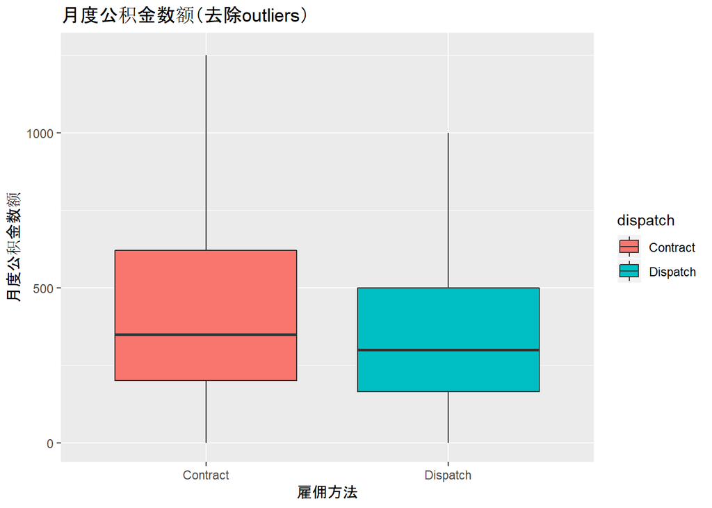

```r
ylim1 = boxplot.stats(employment2018$qg1001)$stats[c(1, 5)]

ggplot(data = subset(employment2018, !is.na(qg1001)), aes(x = dispatch, y = qg1001)) +
  geom_boxplot(aes(fill = dispatch), outlier.shape = NA) +
  labs(x = "雇佣方法", y = "月度公积金数额") +
  ggtitle("月度公积金数额（去除outliers）") +
  coord_cartesian(ylim = ylim1 * 1.05)
```

#### 个人每月缴纳保险

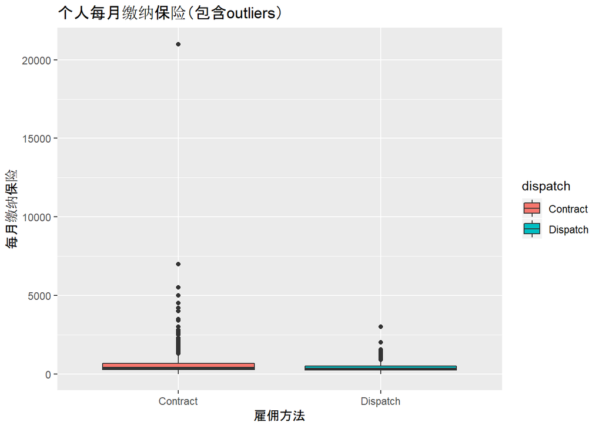

```r
ggplot(data = subset(employment2018, !is.na(qg901)), aes(x = dispatch, y = qg901)) +
  geom_boxplot(aes(fill = dispatch)) +
  labs(x = "雇佣方法", y = "每月缴纳保险") +
  ggtitle("个人每月缴纳保险（包含outliers）")
```

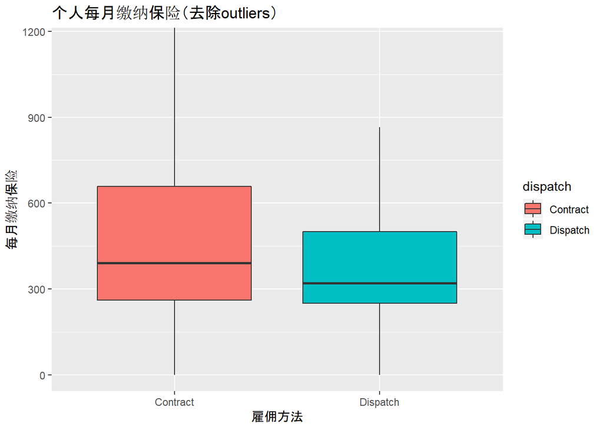

```r
ylim1 = boxplot.stats(employment2018$qg901)$stats[c(1, 5)]

ggplot(data = subset(employment2018, !is.na(qg901)), aes(x = dispatch, y = qg901)) +
  geom_boxplot(aes(fill = dispatch), outlier.shape = NA) +
  labs(x = "雇佣方法", y = "每月缴纳保险") +
  ggtitle("个人每月缴纳保险（去除outliers）") +
  coord_cartesian(ylim = ylim1 * 1.05)
```

#### 过去一年福利金额

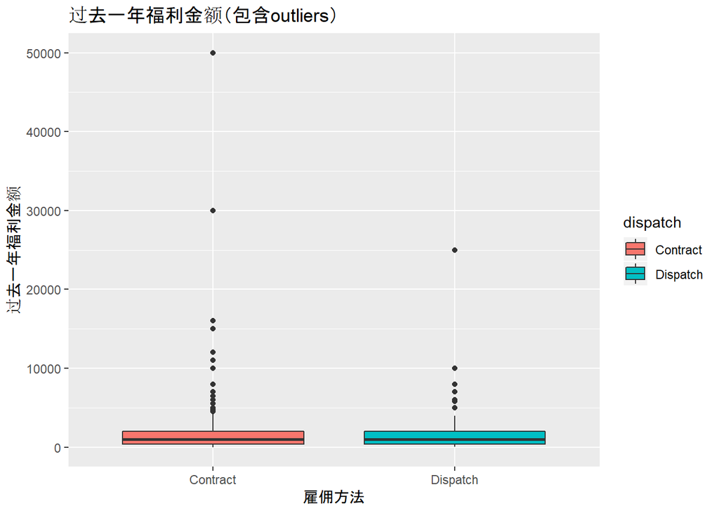

```r
ggplot(data = subset(employment2018, !is.na(qg702)), aes(x = dispatch, y = qg702)) +
  geom_boxplot(aes(fill = dispatch)) +
  labs(x = "雇佣方法", y = "过去一年福利金额") +
  ggtitle("过去一年福利金额（包含outliers）")
```

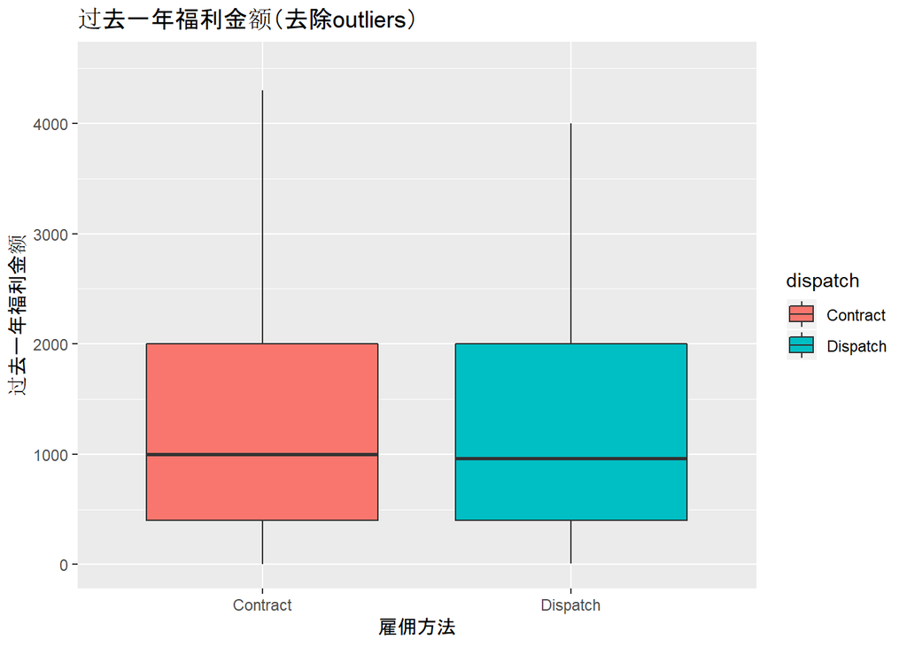

```r
ylim1 = boxplot.stats(employment2018$qg702)$stats[c(1, 5)]

ggplot(data = subset(employment2018, !is.na(qg702)), aes(x = dispatch, y = qg702)) +
  geom_boxplot(aes(fill = dispatch), outlier.shape = NA) +
  labs(x = "雇佣方法", y = "过去一年福利金额") +
  ggtitle("过去一年福利金额（去除outliers）") +
  coord_cartesian(ylim = ylim1 * 1.05)
```

### Conditional Probability

用conditional probability测试以下7个变量

| Num | var | label |
| --- | --- | --- |
| 1 | qg401 | 工作收入满意度 |
| 2 | qg406 | 工作总体满意度 |
| 3 | qg15 | 过去12个月是否升迁 |
| 4 | qn10025 | 对政府官员信任程度 |
| 5 | qn6011 | 认为政府腐败问题有多严重 |
| 6 | qn6014 | 我国就业问题有多严重 |
| 7 | qn6018 | 我国社会保障问题有多严重 |

#### 工作收入满意程度

qg401 = 1 非常不满意

qg401 = 2 不太满意

求值P(qg401 = 1 or 2 | dispatch == “Dispatch”) vs. P(qg401 == 1 or 2 | dispatch == “Contract”)

**劳务派遣工人对工作收入不满意概率为0.227，略高于合同工人0.217**

```r
probDispatch <- length(which(!is.na(employment2018$qg401) & employment2018$qg401 > 0 & employment2018$dispatch == "Dispatch")) / length(which(!is.na(employment2018$qg401) & employment2018$qg401 > 0))

probContract <- length(which(!is.na(employment2018$qg401) & employment2018$qg401 > 0 & employment2018$dispatch == "Contract")) / length(which(!is.na(employment2018$qg401) & employment2018$qg401 > 0))

probDisUnsatisfied <- length(which(!is.na(employment2018$qg401) & employment2018$qg401 > 0 & employment2018$dispatch == "Dispatch" & (employment2018$qg401 == 1 | employment2018$qg401 == 2))) / length(which(!is.na(employment2018$qg401) & employment2018$qg401 > 0))

probConUnsatisfied <- length(which(!is.na(employment2018$qg401) & employment2018$qg401 > 0 & employment2018$dispatch == "Contract" & (employment2018$qg401 == 1 | employment2018$qg401 == 2))) / length(which(!is.na(employment2018$qg401) & employment2018$qg401 > 0))

unsatGivDis <- probDisUnsatisfied / probDispatch

unsatGivCon <- probConUnsatisfied / probContract

unsatGivDis
```

```
## [1] 0.2273731
```

```r
unsatGivCon
```

```
## [1] 0.2172832
```

#### 工作总体满意度

qg406 = 1 非常不满意

qg406 = 2 不太满意

求值P(qg406 = 1 or 2 | dispatch == “Dispatch”) vs. P(qg406 == 1 or 2 | dispatch == “Contract”)

```r
probDispatch <- length(which(!is.na(employment2018$qg406) & employment2018$qg406 > 0 & employment2018$dispatch == "Dispatch")) / length(which(!is.na(employment2018$qg406) & employment2018$qg406 > 0))

probContract <- length(which(!is.na(employment2018$qg406) & employment2018$qg406 > 0 & employment2018$dispatch == "Contract")) / length(which(!is.na(employment2018$qg406) & employment2018$qg406 > 0))

probDisUnsatisfied <- length(which(!is.na(employment2018$qg406) & employment2018$qg406 > 0 & employment2018$dispatch == "Dispatch" & (employment2018$qg406 == 1 | employment2018$qg406 == 2))) / length(which(!is.na(employment2018$qg406) & employment2018$qg406 > 0))

probConUnsatisfied <- length(which(!is.na(employment2018$qg406) & employment2018$qg406 > 0 & employment2018$dispatch == "Contract" & (employment2018$qg406 == 1 | employment2018$qg406 == 2))) / length(which(!is.na(employment2018$qg406) & employment2018$qg406 > 0))

unsatGivDis <- probDisUnsatisfied / probDispatch

unsatGivCon <- probConUnsatisfied / probContract

unsatGivDis
```

```
## [1] 0.1092715
```

```r
unsatGivCon
```

```
## [1] 0.1025482
```

#### 过去12月是否升迁

qg15 = 1 行政职务晋升

qg15 = 2 行政职务晋升

qg15 = 3 两项都有

求值P(qg15 = 1 or 2 or 3 | dispatch == “Dispatch”) vs. P(qg15 == 1 or 2 or 3 | dispatch == “Contract”)

**劳务派遣工人过去12月晋升概率为0.136，略低于合同工人0.141**

```r
probDispatch <- length(which(!is.na(employment2018$qg15) & employment2018$qg15 > 0 & employment2018$dispatch == "Dispatch")) / length(which(!is.na(employment2018$qg15) & employment2018$qg15 > 0))

probContract <- length(which(!is.na(employment2018$qg15) & employment2018$qg15 > 0 & employment2018$dispatch == "Contract")) / length(which(!is.na(employment2018$qg15) & employment2018$qg15 > 0))

probDisProm <- length(which(!is.na(employment2018$qg15) & employment2018$qg15 > 0 & employment2018$dispatch == "Dispatch" & (employment2018$qg15 == 1 | employment2018$qg15 == 2 | employment2018$qg15 == 3))) / length(which(!is.na(employment2018$qg15) & employment2018$qg15 > 0))

probConProm <- length(which(!is.na(employment2018$qg15) & employment2018$qg15 > 0 & employment2018$dispatch == "Contract" & (employment2018$qg15 == 1 | employment2018$qg15 == 2 | employment2018$qg15 == 3))) / length(which(!is.na(employment2018$qg15) & employment2018$qg15 > 0))

promGivDis <- probDisProm / probDispatch

promGivCon <- probConProm / probContract

promGivDis
```

```
## [1] 0.1356502
```

```r
promGivCon
```

```
## [1] 0.1408848
```

#### 对政府官员信任程度

qn10025 on a scale of 1-10.

求值P(qn10025 < 3 | dispatch == “Dispatch”) vs. P(qn10025 < 3 | dispatch == “Contract”)

**劳务派遣工人对政府官员不信任概率为0.132，略高于合同工人0.106**

```r
probDispatch <- length(which(!is.na(employment2018$qn10025) & employment2018$qn10025 > 0 & employment2018$dispatch == "Dispatch")) / length(which(!is.na(employment2018$qn10025) & employment2018$qn10025 > 0))

probContract <- length(which(!is.na(employment2018$qn10025) & employment2018$qn10025 > 0 & employment2018$dispatch == "Contract")) / length(which(!is.na(employment2018$qn10025) & employment2018$qn10025 > 0))

probDisDist <- length(which(!is.na(employment2018$qn10025) & employment2018$qn10025 > 0 & employment2018$dispatch == "Dispatch" & employment2018$qn10025 < 3)) / length(which(!is.na(employment2018$qn10025) & employment2018$qn10025 > 0))

probConDist <- length(which(!is.na(employment2018$qn10025) & employment2018$qn10025 > 0 & employment2018$dispatch == "Contract" & employment2018$qn10025 < 3)) / length(which(!is.na(employment2018$qn10025) & employment2018$qn10025 > 0))

distGivDis <- probDisDist / probDispatch

distGivCon <- probConDist / probContract

distGivDis
```

```
## [1] 0.1318017
```

```r
distGivCon
```

```
## [1] 0.1056856
```

#### 认为政府腐败问题有多严重

qn6011 on a scale of 1-10.

求值P(qn6011 > 8 | dispatch == “Dispatch”) vs. P(qn6011 > 8 | dispatch == “Contract”)

**劳务派遣工人认为政府腐败问题严重概率为0.350，略高于合同工人0.324**

```r
probDispatch <- length(which(!is.na(employment2018$qn6011) & employment2018$qn6011 > 0 & employment2018$dispatch == "Dispatch")) / length(which(!is.na(employment2018$qn6011) & employment2018$qn6011 > 0))

probContract <- length(which(!is.na(employment2018$qn6011) & employment2018$qn6011 > 0 & employment2018$dispatch == "Contract")) / length(which(!is.na(employment2018$qn6011) & employment2018$qn6011 > 0))

probDisCorr <- length(which(!is.na(employment2018$qn6011) & employment2018$qn6011 > 0 & employment2018$dispatch == "Dispatch" & employment2018$qn6011 > 8)) / length(which(!is.na(employment2018$qn6011) & employment2018$qn6011 > 0))

probConCorr <- length(which(!is.na(employment2018$qn6011) & employment2018$qn6011 > 0 & employment2018$dispatch == "Contract" & employment2018$qn6011 > 8)) / length(which(!is.na(employment2018$qn6011) & employment2018$qn6011 > 0))

corrGivDis <- probDisCorr / probDispatch

corrGivCon <- probConCorr / probContract

corrGivDis
```

```
## [1] 0.3502825
```

```r
corrGivCon
```

```
## [1] 0.3247918
```

#### 认为就业问题有多严重

qn6014 on a scale of 1-10.

求值P(qn6014 > 8 | dispatch == “Dispatch”) vs. P(qn6014 > 8 | dispatch == “Contract”)

**劳务派遣工人认为就业问题问题严重概率为0.242，略高于合同工人0.210**

```r
probDispatch <- length(which(!is.na(employment2018$qn6014) & employment2018$qn6014 > 0 & employment2018$dispatch == "Dispatch")) / length(which(!is.na(employment2018$qn6014) & employment2018$qn6014 > 0))

probContract <- length(which(!is.na(employment2018$qn6014) & employment2018$qn6014 > 0 & employment2018$dispatch == "Contract")) / length(which(!is.na(employment2018$qn6014) & employment2018$qn6014 > 0))

probDisJob <- length(which(!is.na(employment2018$qn6014) & employment2018$qn6014 > 0 & employment2018$dispatch == "Dispatch" & employment2018$qn6014 > 8)) / length(which(!is.na(employment2018$qn6014) & employment2018$qn6014 > 0))

probConJob <- length(which(!is.na(employment2018$qn6014) & employment2018$qn6014 > 0 & employment2018$dispatch == "Contract" & employment2018$qn6014 > 8)) / length(which(!is.na(employment2018$qn6014) & employment2018$qn6014 > 0))

jobGivDis <- probDisJob / probDispatch

jobGivCon <- probConJob / probContract

jobGivDis
```

```
## [1] 0.2429696
```

```r
jobGivCon
```

```
## [1] 0.2103275
```

#### 认为社会保障问题有多严重

qn6018 on a scale of 1-10.

求值P(qn6018 > 8 | dispatch == “Dispatch”) vs. P(qn6018 > 8 | dispatch == “Contract”)

**劳务派遣工人认为社会保障问题严重概率为0.260，略高于合同工人0.230**

```r
probDispatch <- length(which(!is.na(employment2018$qn6018) & employment2018$qn6018 > 0 & employment2018$dispatch == "Dispatch")) / length(which(!is.na(employment2018$qn6018) & employment2018$qn6018 > 0))

probContract <- length(which(!is.na(employment2018$qn6018) & employment2018$qn6018 > 0 & employment2018$dispatch == "Contract")) / length(which(!is.na(employment2018$qn6018) & employment2018$qn6018 > 0))

probDisSS <- length(which(!is.na(employment2018$qn6018) & employment2018$qn6018 > 0 & employment2018$dispatch == "Dispatch" & employment2018$qn6018 > 8)) / length(which(!is.na(employment2018$qn6018) & employment2018$qn6018 > 0))

probConSS <- length(which(!is.na(employment2018$qn6018) & employment2018$qn6018 > 0 & employment2018$dispatch == "Contract" & employment2018$qn6018 > 8)) / length(which(!is.na(employment2018$qn6018) & employment2018$qn6018 > 0))

ssGivDis <- probDisSS / probDispatch

ssGivCon <- probConSS / probContract

ssGivDis
```

```
## [1] 0.260181
```

```r
ssGivCon
```

```
## [1] 0.2304279
```